# Role model effects & women’s political engagement

EPOP Annual Meeting, September 9, 2016

## Gender gaps

- political engagement
- political efficacy
- political knowledge
- (Dolan, 2011; Wolbrecht & Campbell, 2007)

## Literature overview

- Stereotype threat
- Role model effects
- Social identity

## Stereotype threat

- Racial context (Steele & Aronson, 1995)
- Performance anxiety in testing
- Effects on women's performnce on political knowledge test (McGlone et. al., 2006)

## Role model effects

- Women's career efficacy (e.g. Shapiro & Williams, 2012; Dasgupta et. al., 2015)
- Beaman et. al. (2012) natural experiment
- Women's leadership aspirations (Latu et. al., 2013)
- Political engagement?

## Role model effects from (numerical) representation

- Put the original idea into experimental context
- Wolbrecht and Campbell, 2007
- Is it women's visibility?
- At what numerical advantage?
- What about impacts on men?

## Adverse role model effects?

- Social identity literature
- Increasing social distance
- Unattainable achievements
- No identification with female politicians

## Research design

- Online experiment
- Exposure to political discussion groups: picture viewing/rating task
- Randomised across 4 groups: varying numerical balance
- Survey of political efficacy, political knowledge, confidence about performance (and political values)

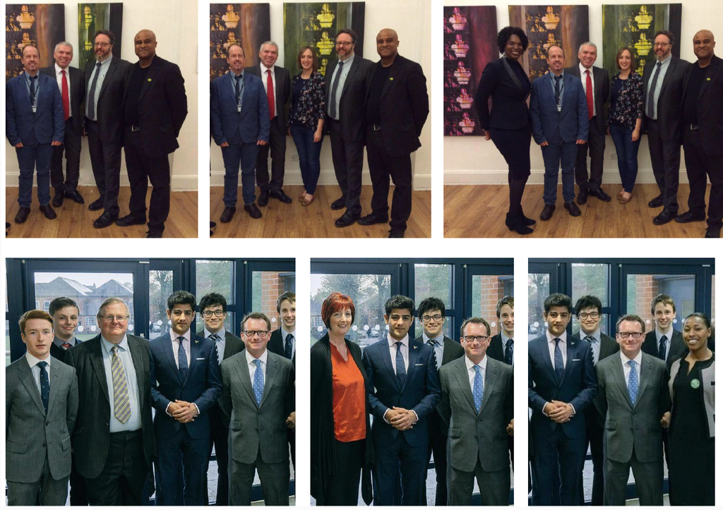

## Overview of sample

```
##    treat woman  N
## 1:   ST1     0 41
## 2:   ST1     1 51
## 3:   ST2     0 41
## 4:   ST2     1 39
## 5:   ST3     0 40
## 6:   ST3     1 47
## 7:   ST4     0 38
## 8:   ST4     1 32
```

```
##    woman sample   N
## 1:     0     CF  68
## 2:     1     CF  57
## 3:     0     PA  92
## 4:     1     PA 112
```

## Political Interest / model

\[y_{ij} = \beta_0 + \beta^{age}_{ij} + \beta^{edu.}_{ij} + \beta^{race}_{ij} + \beta^{sample}_{ij} + u^{gender}_{j[i]} + u^{treatment}_{ij} + \epsilon_{ij}\]

```
##      treatST2    treatST3    treatST4 (Intercept)   samplePA        age
## 0 -0.03431853 -0.02182598 -0.01027174    2.614204 -0.1059047 0.01096964
## 1  0.13879587  0.08827174  0.04154242    2.434214 -0.1059047 0.01096964
##        uni1    white1
## 0 0.1851511 -0.127867
## 1 0.1851511 -0.127867
```

## Political Interest / simulations

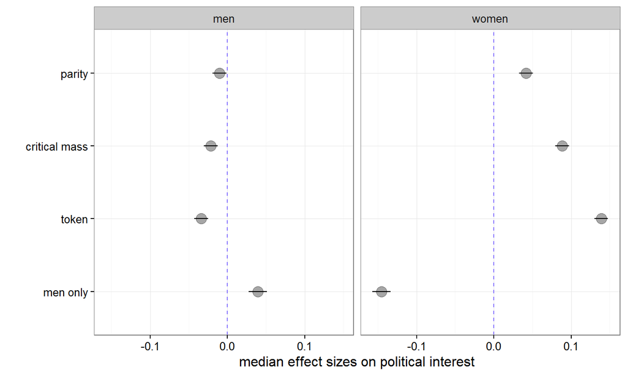

## Political Efficacy / model

- item level model, with multiple nesting:
- within **individuals**,
- **efficacy measures**,
- **efficacy types (internal vs. external)**, and
- **gender/treatment**

\[ \begin{aligned} Pr(y_i = 1) &= logit^{-1}(\beta_0 + \beta^{age}_{ij} + \beta^{edu.}_{ij} + \beta^{race}_{ij} + \beta^{sample}_{ij} + \\ &+ u^{gender*treatment}_{j[i]} + u^{eff.type}_{ij} + u^{item}_{j[i]} + u^{participant}_{j[i]} + \epsilon_{ij} \end{aligned} \]

## Political Efficacy / internal vs external

- I have a pretty good understanding of the important political issues facing our country.
- It takes too much time and effort to be active in politics and public affairs.
- It is often difficult for me to understand what is going on in government and politics.
- Politicians don't care what people like me think.
- Going to vote is a lot of effort.
- Voting is an enjoyable experience.
- People who vote for small parties are throwing away their vote.
- People should vote for the party they like the most, even if it's not likely to win.
- It doesn't matter which political party is in power.

## Political Efficacy / internal vs external

- search algorithm
- computes scalability coefficients

```
##
## SCALE 1
##
## Item:  eff3                  Scale 1  H =  0.6
## Item:  eff1                  Scale 1  H =  0.6
## Item:  eff2                  Scale 1  H =  0.46
## Scale  1  is completed. No items left such that Hi >  0.3 .
##
## SCALE 2
##
## Item:  eff9                  Scale 2  H =  0.43
## Item:  eff5                  Scale 2  H =  0.43
## Scale  2  is completed. No items left such that Hi >  0.3 .
##
## SCALE 3
##
## Scale  3  could not be formed due to H <  0.3 . PROCEDURE STOPS
```

```
## [1] 1
```

## Political Efficacy / internal vs external

- I have a pretty good understanding of the important political issues facing our country.
- It takes too much time and effort to be active in politics and public affairs.
- It is often difficult for me to understand what is going on in government and politics.-
- Going to vote is a lot of effort.
- It doesn't matter which political party is in power.

## Political Efficacy / model fit

```
## Generalized linear mixed model fit by maximum likelihood (Laplace
##   Approximation) [glmerMod]
##  Family: binomial  ( logit )
## Formula: eff ~ (1 | id) + (1 + itype | treat.o:woman) + (1 | variable) +
##     sample + age + uni + white
##    Data: eff.m
##       AIC       BIC    logLik  deviance  df.resid
## 1872.5409 1926.1927 -926.2705 1852.5409      1570
## Random effects:
##  Groups        Name          Std.Dev. Corr
##  id            (Intercept)   1.3384
##  treat.o:woman (Intercept)   0.1759
##                itypeinternal 0.3892   -1.00
##  variable      (Intercept)   0.9099
## Number of obs: 1580, groups:  id, 316; treat.o:woman, 8; variable, 5
## Fixed Effects:
## (Intercept)     samplePA          age         uni1       white1
##    -0.74645      0.10539      0.01935      0.47278      0.24006
```

## Political Efficacy / simulations

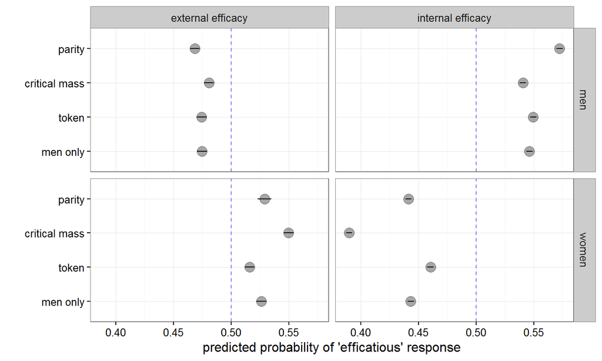

## Political Efficacy / check on scale items

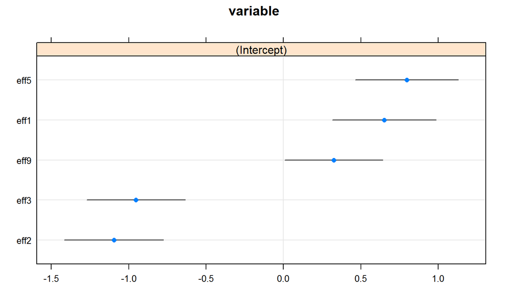

## Political Knowledge / two models

- self report
- test score model: of 6 true/false selected items

## Political Knowledge / self report, simulation

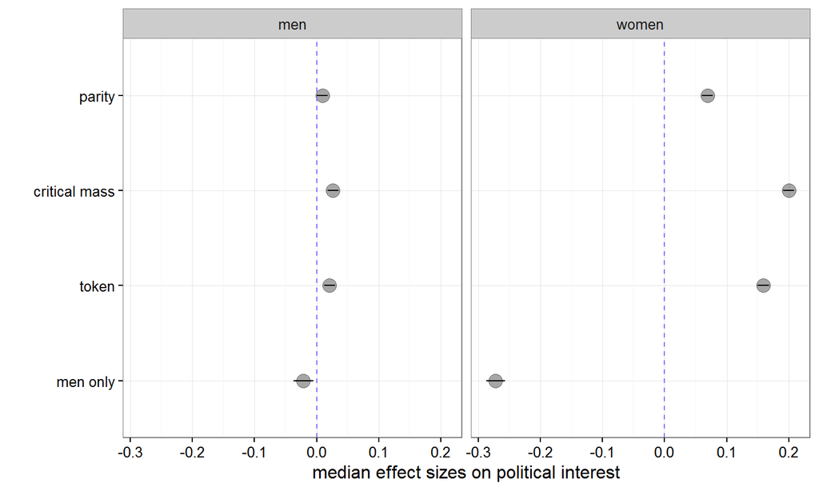

## Political Knowledge / test scores, simulation

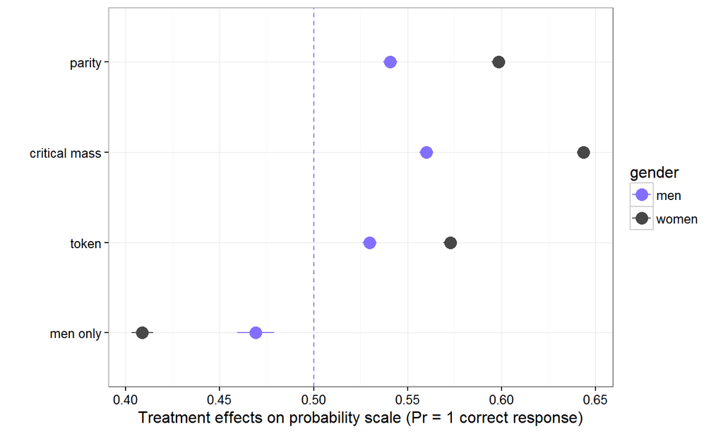

## Confidence about political knowledge

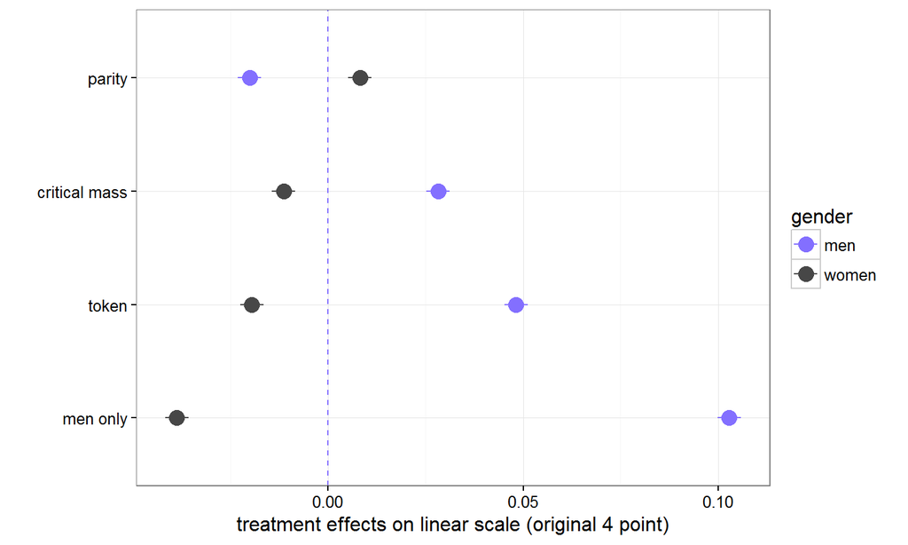

## Preliminary conclusions

- non-linear treatment effects
- effects typically kick-off trends at token presence
- tokenism: impacts on men's efficacy and confidence

## Next step

- pit findings against observational data: Media in Context GE 2015

## (we have more data)

- lab experiment: attentional bias to female members (same pictures)
- analysing political values
- analysing voting propensities